# TP single-cell RNA-Seq analysis with Seurat

### 3.7. Choix du nombre de dimensions

Plusieurs visualisations permettent de décider du nombre de dimensions retenues. D’abord, **une *heatmap* permet de visualiser le pouvoir “discriminant” de chaque composante principale sur les cellules** (cf 2.7 pour l’explication détaillée du principe des heatmap).

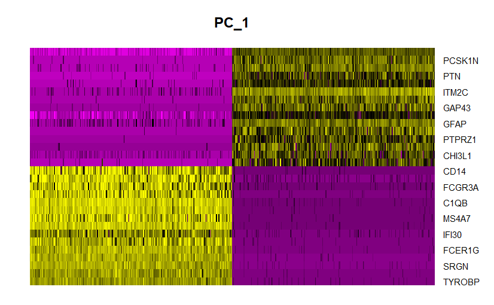

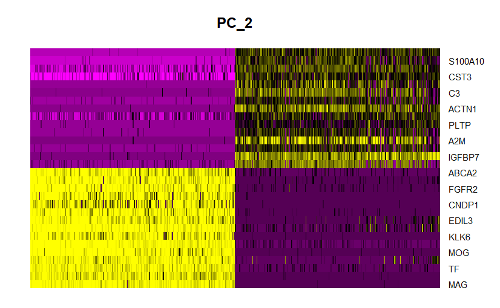

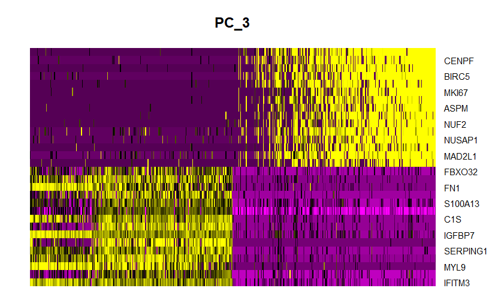

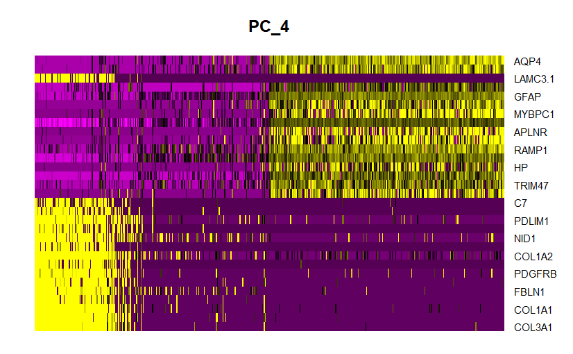

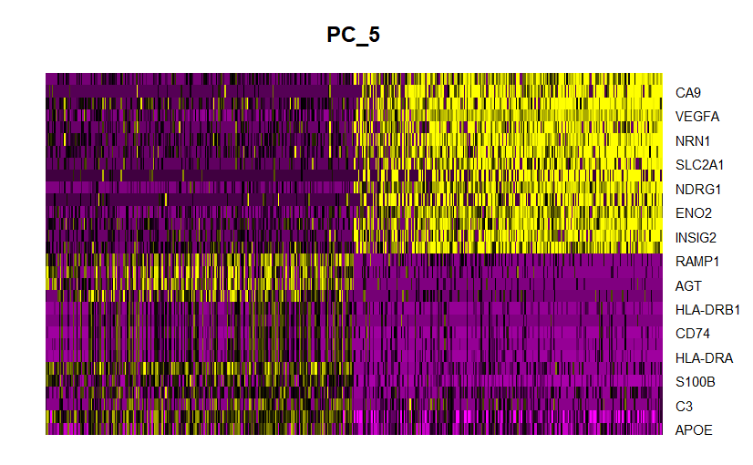

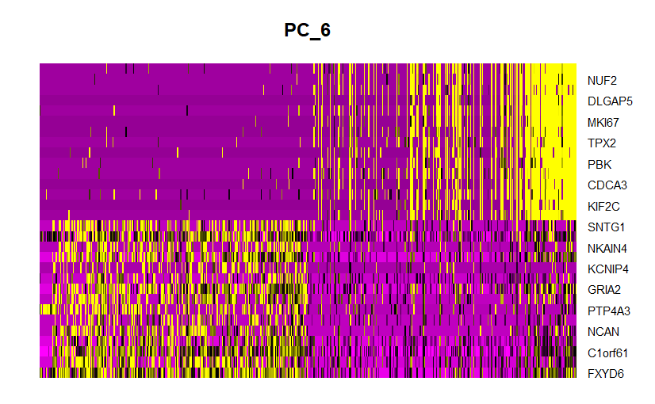

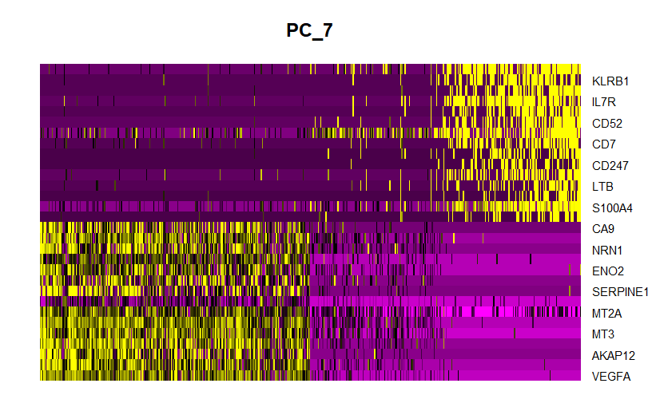

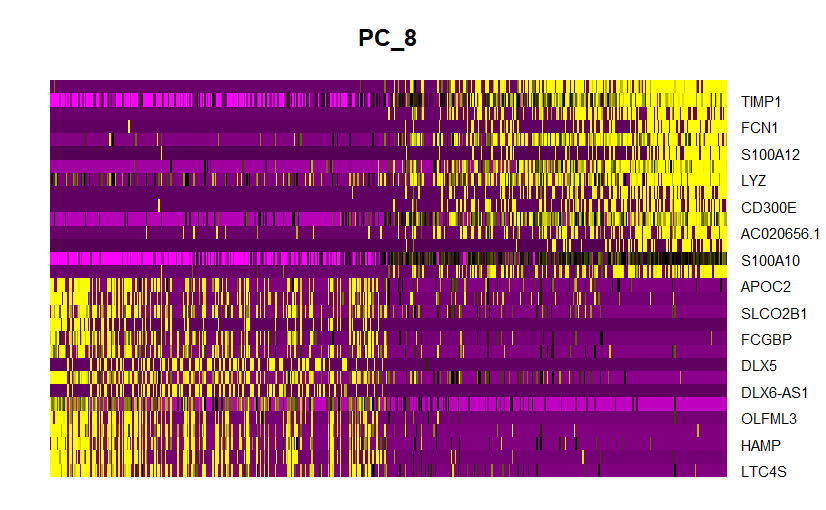

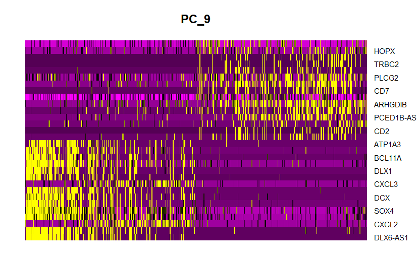

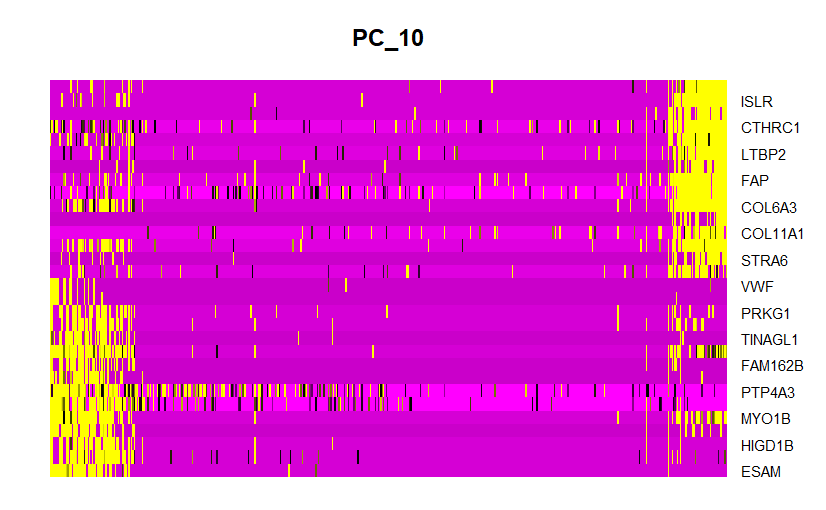

```r
for (i in 1:10){
  DimHeatmap(gliob, dims = i, cells = 500, balanced = TRUE)
  }
```

**On regarde le graphique de la variance expliquée pour prendre une décision sur le nombre de PC à retenir.**

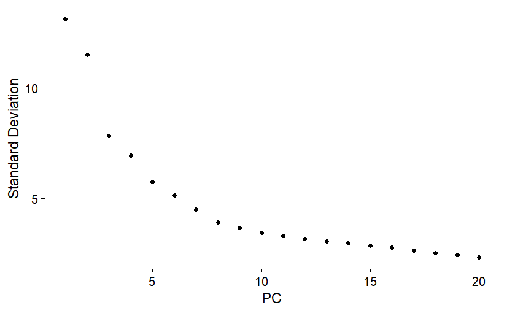

**Nous allons ainsi retenir les 10 premières composantes principales pour le clustering.**

### 3.8. Clustering

**Le clustering s’appuie sur la distance euclidienne calculée lors de l’ACP et sur l’utilisation d’un graphe des k-plus proches voisins.** Les sommets de ce graphe sont des **cellules**, et des arcs relient entre elles les **cellules présentant des motifs d’expression similaires**. Les clusters sont ensuite obtenus par partitionnement de ce graphe dans des groupes qui présentent beaucoup d’interconnexions. La méthode a été développée par V. Blondel et al., elle est expliquée dans l’article [*Fast unfolding of communities in large networks*](https://iopscience.iop.org/article/10.1088/1742-5468/2008/10/P10008).

Le code suivant permet de réaliser le clustering :

```r
gliob <- FindClusters(gliob, resolution = 0.8)
```

```
Modularity Optimizer version 1.3.0 by Ludo Waltman and Nees Jan van Eck

Number of nodes: 4853
Number of edges: 151411

Running Louvain algorithm...
```

```
Maximum modularity in 10 random starts: 0.8787
Number of communities: 17
Elapsed time: 0 seconds
```

**À l’issue du clustering, on trouve 17 clusters.** Cela paraît élevé, mais il sera possible de regrouper des clusters en un seul.

### 3.9. UMAP

La UMAP est un **outil de réduction de dimension non linéaire**. Elle permet une visualisation en 2D des composantes retenues précédemment. Les cellules attribuées à un même cluster dans l’étape précédente apparaissent proches dans la UMAP.

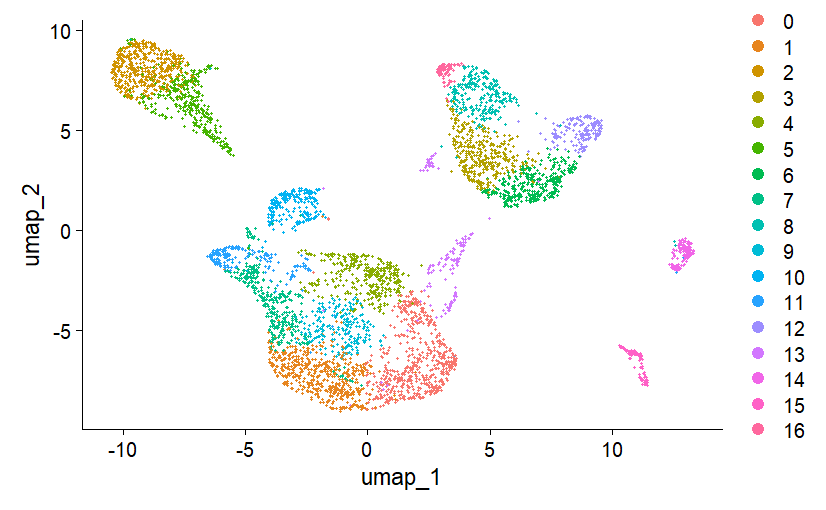

### 3.10. Gènes exprimés différentiellement

L’objectif est d’attribuer des **étiquettes** aux différents clusters.

Pour cela, on cherche à déterminer **quels gènes sont exprimés préférentiellement par certains clusters par rapport aux autres**.

Ainsi, on obtient des **biomarqueurs** pour chaque cluster, qui permetteront par la suite d’attribuer le cluster à un groupe de cellules :

```r
gliob.markers <- FindAllMarkers(gliob, only.pos = TRUE)
```

```r
gliob.markers %>%
  group_by(cluster) %>%
  dplyr::filter(avg_log2FC > 1)

# On affiche les 6 gènes les plus "caractéristiques" de chaque cluster (par p-value décroissantes) :
for (i in 0:16){
  print(head(gliob.markers[gliob.markers$cluster==i, ])) }
```

On trouve les marqueurs suivants pour chaque cluster :

[output not shown]

- **Exemple 1 :**

On cherche à localiser les **macrophages**. On sait que ceux-ci sont fortement présents dans le glioblastome et qu’ils expriment les marqueurs **CD68 et AIF1** (= IBA1).

Parmi ces macrophages, il y a un grand nombre de **TAM** (*Tumor Associated Macrophages*), qui dérivent de **monocytes** et de **microglies activées**, dites “infiltrantes”.

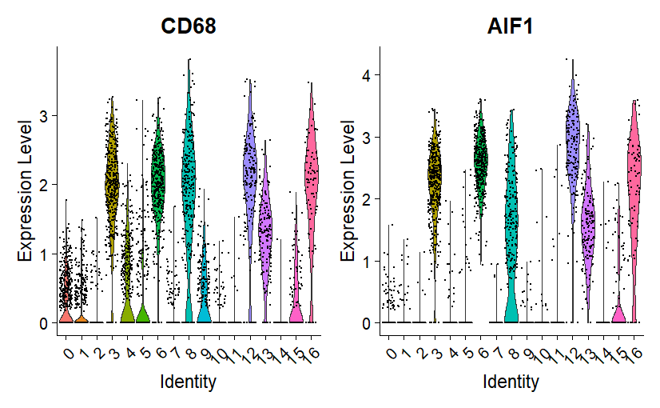

```r
VlnPlot(gliob, features = c("CD68", "AIF1"))
```

D’abord, on remarque que les profils d’expression de CD68 et AIF1 sont **très proches**.

D’après la partie **3.11**, les clusters proposés par ChatGPT pour les macrophages y compris les TAM sont les clusters **3, 6, 8, 12, 13**. Cela semble concorder avec le graphique ci-dessus, où **les pics d’expression ont lieu pour ces clusters-là.**

Toutefois, on remarque que les gènes CF68 et AIF1 sont également exprimés fortement par les cellules du **cluster 16,** qui ont été étiquetées en tant que **cellules épidermiques**. Soit cela est dû à une erreur d’étiquettage, soit cela signifie que ces cellules épidermiques peuvent exprimer CD68 et AIF1 au même niveau que les macrophages.

Cherchons un gène qui permettrait de distinguer le **cluster 16** des autres clusters :

|  | p_val | avg_log2FC | pct.1 | pct.2 | p_val_adj |
| --- | --- | --- | --- | --- | --- |
| S100A12 | 8.140134e-99 | 4.753014 | 0.645 | 0.033 | 1.983181e-94 |
| FCN1 | 3.033573e-91 | 4.745927 | 0.658 | 0.040 | 7.390693e-87 |
| SERPINB2 | 1.346569e-76 | 4.983554 | 0.500 | 0.024 | 3.280646e-72 |
| CFP | 2.396351e-69 | 4.179121 | 0.474 | 0.025 | 5.838230e-65 |
| EREG | 3.775015e-48 | 3.348470 | 0.908 | 0.249 | 9.197070e-44 |

**S100A12** permettrait de distinguer les clusters 3, 6, 8, 12, 13 du cluster 16.

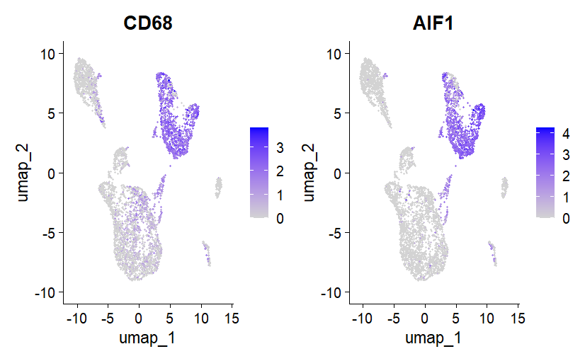

Ce graphique montre le niveau d’expression des gènes CD68 et AIF1 spatialement, sur la UMAP. Ainsi, les **macrophages** sont co-localisés dans une zone en haut à droite de la UMAP, recouvrant **plusieurs clusters.**

- **Exemple 2 :**

On cherche à localiser les **cellules souches de glioblastome**. Canoniquement, elles expriment préférentiellement les gènes **ROM1, NES, SOX2, et OLIG2**.

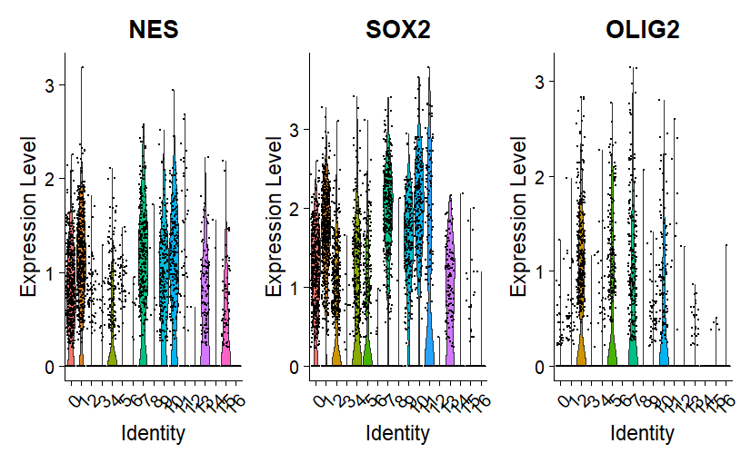

Les clusters qui expriment préférentiellement les trois gènes sont : **7 et 10**.

En effet, on exclut les cluster 2 et 5 car leurs cellules expriment **trop peu** le gène NES.

On retrouve bien le cluster 7 que ChatGPT avait étiqueté **précurseurs neuronaux**.

### 3.11. Attribution des étiquettes

À l’issue de l’analyse des gènes exprimés différentiellement, ChatGPT a attribué les étiquettes suivantes aux clusters :

| **Cluster** | **Marqueurs utilisés** | **Nouvelles étiquettes (types cellulaires ou sous-populations)** |
| --- | --- | --- |

| **0** | VCAM1, EFEMP1, RARRES2 | **Cellules endothéliales vasculaires** – impliquées dans l’angiogenèse tumorale. |
| --- | --- | --- |

| **1** | PPP1R1B, AQP4, FADS2, GFAP, MLC1, ITM2C | **Astrocytes réactifs** – liés à l’œdème péritumoral. |
| --- | --- | --- |

| **2** | MOG, MAG, CARNS1, KLK6, NKX6-2, EDIL3 | **Oligodendrocytes matures / myélinisants** – rôle clé dans la production et l’entretien de la myéline. |
| --- | --- | --- |

| **3** | MS4A7, GPR183, C1QC, STAB1, OLR1, C1QA | **Macrophages M2 associés aux tumeurs (TAMs)** – phénotype immunosuppresseur. |
| --- | --- | --- |

| **4** | CA9, AKAP12, IGFBP3, NRN1, TRIB3, VEGFA | **Cellules endothéliales activées** – impliquées dans la néovascularisation du glioblastome. |
| --- | --- | --- |

| **5** | NKX6-2, CLDN11, MAG, KLK6, CNDP1, PLPP2 | **Oligodendrocytes différenciés** – impliqués dans la myélinisation. |
| --- | --- | --- |

| **6** | TREM2, MS4A6A, HAMP | **Microglies activées** – rôle dans l’inflammation et la phagocytose. |
| --- | --- | --- |

| **7** | PTPRZ1, ASCL1, GRIA2 | **Précurseurs neuronaux / cellules progénitrices** – associées aux cellules souches neurales. |
| --- | --- | --- |

| **8** | C15orf48, SLAMF9, CXCL8, TPT1, LSP1, PLIN2 | **Monocytes pro-inflammatoires** – impliqués dans la réponse immunitaire innée. |
| --- | --- | --- |

| **9** | F3, HOPX, NCAN | **Cellules gliales immatures** – marqueurs associés aux cellules progénitrices gliales. |
| --- | --- | --- |

| **10** | TOPK, PBK, BIRC5 | **Cellules tumorales prolifératives** – gènes liés à la division cellulaire et aux tumeurs agressives. |
| --- | --- | --- |

| **11** | DLX6-AS1, DLX5, DCX | **Neuroblastes immatures** – impliqués dans le développement neuronal. |
| --- | --- | --- |

| **12** | ADORA3, TREM2, MNDA | **Macrophages M1 pro-inflammatoires** – réponse immunitaire active contre la tumeur. |
| --- | --- | --- |

| **13** | FCGBP, CCL4L2, TMIGD3 | **Macrophages activés / cellules immunitaires mixtes** – impliqués dans l’inflammation et l’immunité innée. |
| --- | --- | --- |

| **14** | KLRB1, CD3D, TRBC2, CD3E, CD2, IL7R | **Lymphocytes T cytotoxiques et auxiliaires** – réponse immunitaire adaptative. |
| --- | --- | --- |

| **15** | COL3A1, DCN, COL1A1, PDGFRB, FBLN1, ITGA1 | **Fibroblastes associés au stroma tumoral** – rôle dans le remodelage matriciel. |
| --- | --- | --- |

| **16** | S100A12, FCN1, SERPINB2, EREG | **Cellules épidermiques / cellules de la barrière** – possibles kératinocytes ou cellules associées à l’inflammation. |
| --- | --- | --- |